# Data Visualization in R using GGplot2

September 4 2019

## Objectives

- Learn how to build graphs using geometric objects and aesthetic mappings.
- Create scatter plots, box plots, bar charts, density plots, and histograms.
- Learn how to facet, customize legends, add themes, etc.
- Introduce ggmap.

## Agenda for day one:

- Look at advanced examples of scatter plots
- Cover introductory material:
- How to create a GGplot
- Useful GGplot functions
- GGplot syntax (layered grammar)
- Build advanced plots step by step.

There will also be many opportunities for you to practice as we go.

## The in class example data base

The in class example data base we will be using today is from a large diabetes study (N=71064), the variables of interest are:

- sex [Male, Female]
- age [Numeric]
- weight [Numeric]
- admin_type [Emergency, Elective, Urgent, Missing, Other]
- num_medications [Numeric]
- num_lab_procedures [Numeric]

The name DIABETES_CLASS will be used to refer to this data frame in code.

## Exercise data base

The data base that you will use for the exercises is a smaller study (N=200) that looks at mothers and the birth weights of their babies. Each mother has two births recorded and for each birth, some demographic and medical information is collected.

The name bwt will be used to refer to this data frame in code.

The data dictionary is called bwt_matched Data Dictionary. It is a word document that contains information about the variables.

## Example 1

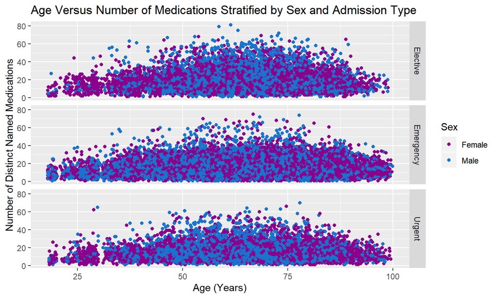

## Example 2

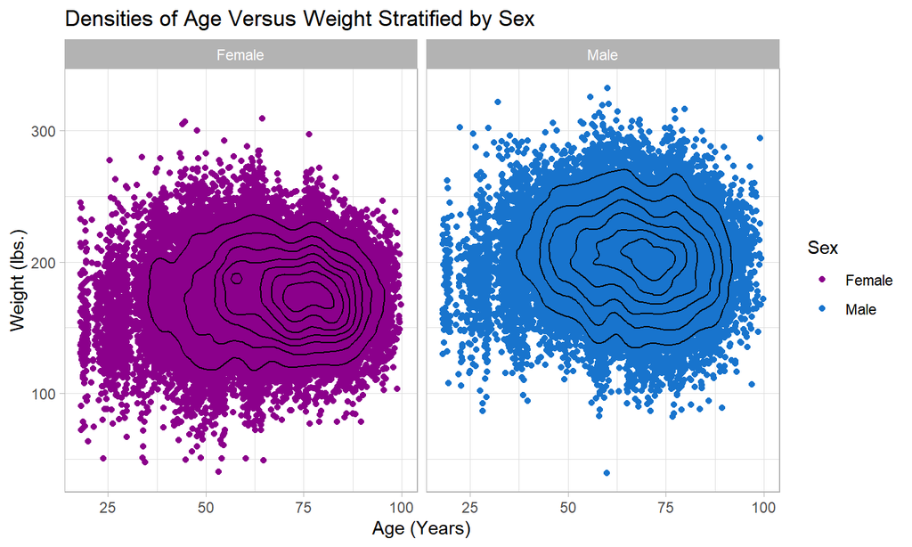

## Example 3

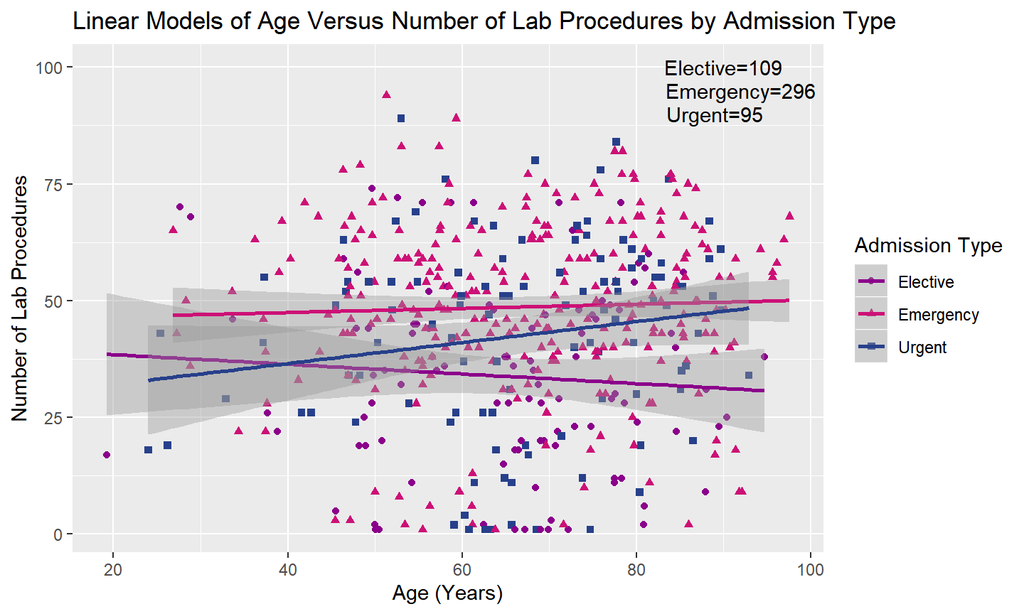

## How to create a GGplot

To create a GGplot you use the ggplot() function, a typical call would look like:

ggplot(df, aes(x, y, other aesthetics))

- df is any data frame (or tibble)
- aes() is used to set your x and y variables, as well as general aesthetics.
- General aesthetics include: color, shape, size, and alpha.

Note that the ggplot() function alone only defines the rules for how your plot will look, if you want to plot your data you must add it in a new layer.

https://ggplot2.tidyverse.org/reference/ggplot.html

## How to create a GGplot

Some useful functions in GGplot:

- geom_point(): plots your data as points
- scale_color_manual(): manually set the color of your plots
- ggtitle(): set the title for the plot
- xlab(), ylab(): set the x and y axis labels
- annotate(): create annotations for your plot

## How to create a GGplot

GGplot has layered grammar, this means that each of GGplot's function can be thought of as a layer. Hence a complete plot can be thought of as many GGplot functions that are linked together. Visually this represents stacked layers.

How exactly do we "link" GGplot functions together?

- We use the plus sign (+) whenever we want to add a new layer onto our plot.

## How to create a GGplot

For example, if we wanted to create a blank plot with a custom title we would do the following

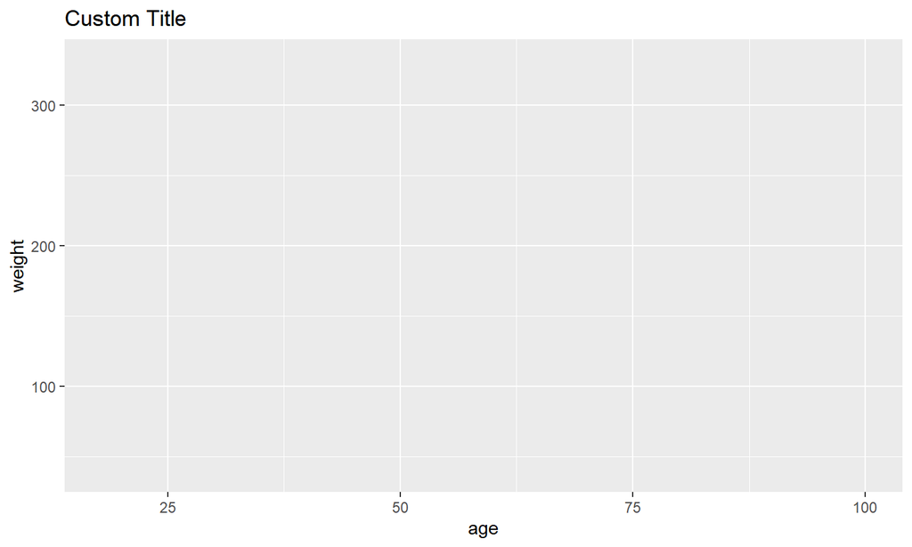

```r
ggplot(DIABETES_CLASS,aes(x=age,y=weight)) + ggtitle(label = "Custom Title")
```

## Exercise 1

## Exercise 1

Lets apply everything we've learned so far using the birth weight data frame.

- 1.) Create a scatter plot of the maternal age vs birth weight at first birth.
- Inside of ggplot() set the data and aesthetics (aes()).
- 2.) Set the color of the data points based on race.
- Recall that color is an aesthetic, so you will want to add something to aes().
- 3.) (Bonus) Apply custom axis labels (Hint: use Google)

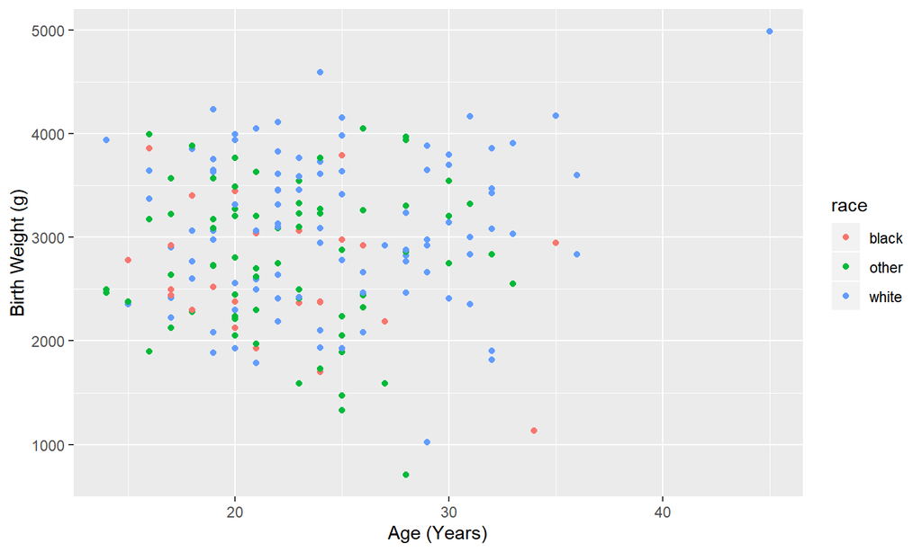

## Recreating Example 1

## Recreating Example 1

Recall what the final plot looks like.

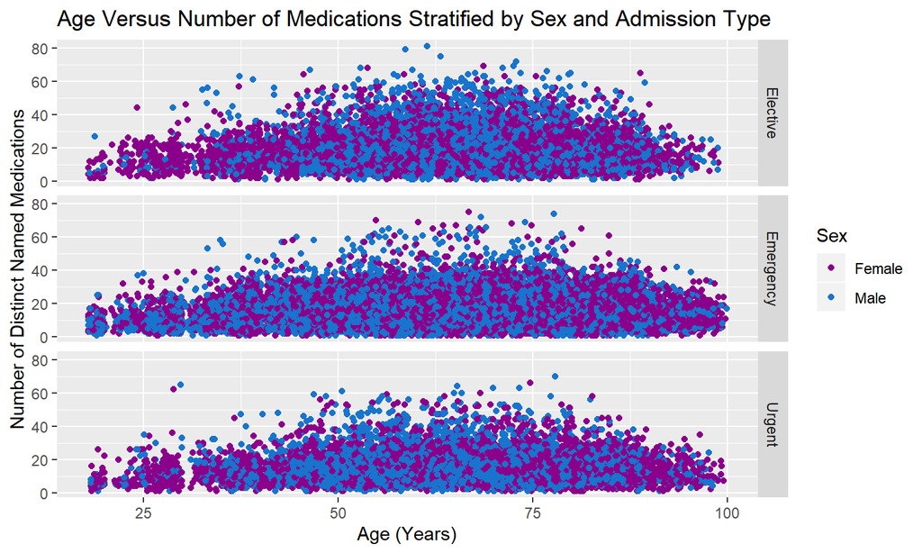

## Recreating Example 1

Create the basic scatter plot.

```r
ggplot(DIABETES_CLASS, aes(x=age, y=num_medications)) + geom_point()
```

## Recreating Example 1

Add a title and touch up the axis labels.

```r
ggplot(DIABETES_CLASS, aes(x=age, y=num_medications)) + geom_point() +
    ggtitle("Age Versus Number of Distinct Medications Stratified by Sex and Admission Type") +
    ylab("Number of Distinct Named Medications") + xlab("Age (Years)")
```

## Recreating Example 1

Add color by sex.

```r
ggplot(DIABETES_CLASS, aes(x=age, y=num_medications, color=sex)) + geom_point() +
    ggtitle("Age Versus Number of Medications Stratified by Sex and Admission Type") +
    ylab("Number of Distinct Named Medications") + xlab("Age (Years)")
```

## Recreating Example 1

Use scale_color_manual() to choose any color.

The following link contains all the predefined colors in GGplot:

http://sape.inf.usi.ch/quick-reference/ggplot2/colour

For more information on manually setting scales:

https://ggplot2.tidyverse.org/reference/scale_manual.html

```r
ggplot(DIABETES_CLASS, aes(x=age, y=num_medications, color=sex)) + geom_point() +
    ggtitle("Age Versus Number of Medications Stratified by Sex and Admission Type") +
    ylab("Number of Distinct Named Medications") + xlab("Age (Years)") +
    scale_color_manual(values=c("magenta4","dodgerblue3"),
                       name = "Sex")
```

## Recreating Example 1

The last thing to do now is use facet_grid() to create subplots of admin type

```r
ggplot(DIABETES_CLASS, aes(x=age, y=num_medications, color=sex)) + geom_point() +
    ggtitle("Age Versus Number of Medications Stratified by Sex and Admission Type") +
    ylab("Number of Distinct Named Medications") + xlab("Age (Years)") +
    scale_color_manual(values=c("magenta4","dodgerblue3"),
                       name = "Sex") +
    facet_grid(admin_type ~ .)
```

## Facets

Facets allow us to divide our data into subplots.

We use the facet_grid() function to achieve this and a typical call would look like:

facet_grid(rows ~ cols)

- rows: placing a variable here will cause its subplots to appear on top of each other (vertically)
- cols: placing a variable here will cause its subplots to appear side by side (horizontally)
- You must place a dot (.) in replacement of rows or cols if you don't want to use it.

https://ggplot2.tidyverse.org/reference/facet_grid.html

## Exercise 2

## Exercise 2

Build a scatter plot that corresponds to the following title:

Maternal Weight Versus Birth Weight at First Birth Stratified by Race and Smoking Status at First Birth

- 1.) Create a basic scatter plot of the appropriate x and y variables using ggplot() and geom_point()
- 2.) Color by smoking status and set manual colors using scale_color_manual()
- 3.) Facet by race using facet_grid().
- 4.) (Bonus) Inside scale_color_manual() set parameters to clean the legend.
- 5.) (Bonus) Using Google, figure out how to clean up the facet labels.

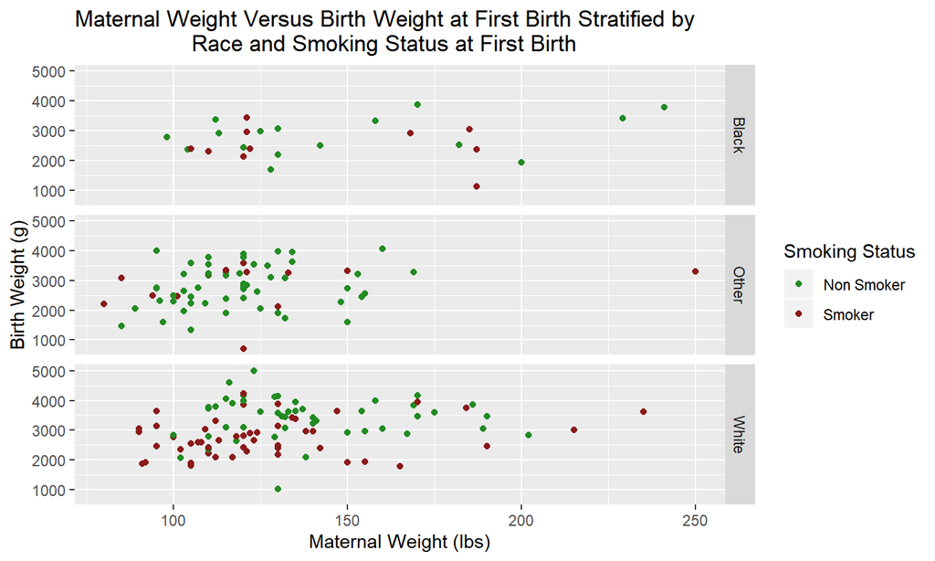

## Recreating Example 2

## Recreating Example 2

If you are working with a large data base one thing you might encounter is over plotting.

One solution to this is to draw a 2d kernel density estimate.

- This allows us to see where the majority of our data is being clustered.
- geom_density_2d() creates the kernel densities.

https://ggplot2.tidyverse.org/reference/geom_density_2d.html

## Recreating Example 2

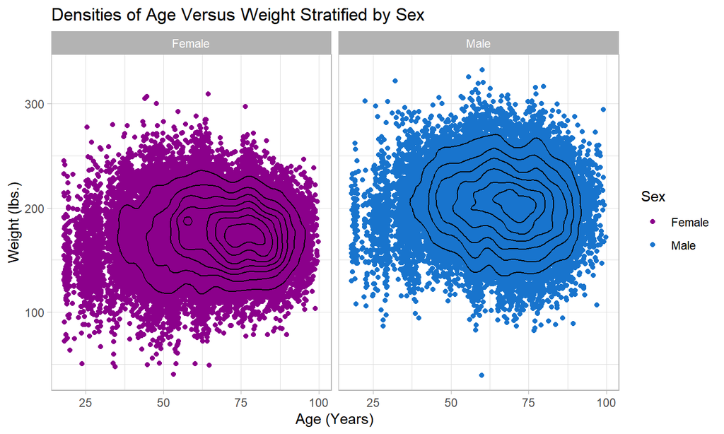

## Recreating Example 2

Start with the basic scatter plot and a title.

```r
ggplot(DIABETES_CLASS,aes(x=age,y=weight)) +
  geom_point() +
  ggtitle(label = "Densities of Age Versus Weight Stratified by Sex")
```

## Recreating Example 2

Add in the colors.

```r
ggplot(DIABETES_CLASS,aes(x=age, y=weight, color=sex)) +
  geom_point() +
  ggtitle(label = "Densities of Age Versus Weight Stratified by Sex") +
  scale_color_manual(values=c("magenta4","dodgerblue3"))
```

## Recreating Example 2

Use geom_density_2d() to plot the 2d kernel density.

- We will need to change the color of the density to override the color options we set in aes()

```r
ggplot(DIABETES_CLASS,aes(x=age, y=weight, color=sex)) +
  geom_point() +
  ggtitle(label = "Densities of Age Versus Weight Stratified by Sex") +
  scale_color_manual(values=c("magenta4","dodgerblue3")) +
  geom_density_2d(color="black")
```

## Recreating Example 2

Facet on sex.

- Notice how the density is automatically drawn for all subplots.

```r
ggplot(DIABETES_CLASS,aes(x=age, y=weight, color=sex)) +
  geom_point() +
  ggtitle(label = "Densities of Age Versus Weight Stratified by Sex") +
  scale_color_manual(values=c("magenta4","dodgerblue3")) +
  geom_density_2d(color="black") +
  facet_grid(. ~ sex)
```

## Recreating Example 2

Lastly, we can add a theme.

- theme_light() is used here, but there are many options such as:
- theme_gray(), theme_bw(), theme_linedraw(), theme_dark(), ect…

For a list of complete themes:

https://ggplot2.tidyverse.org/reference/ggtheme.html

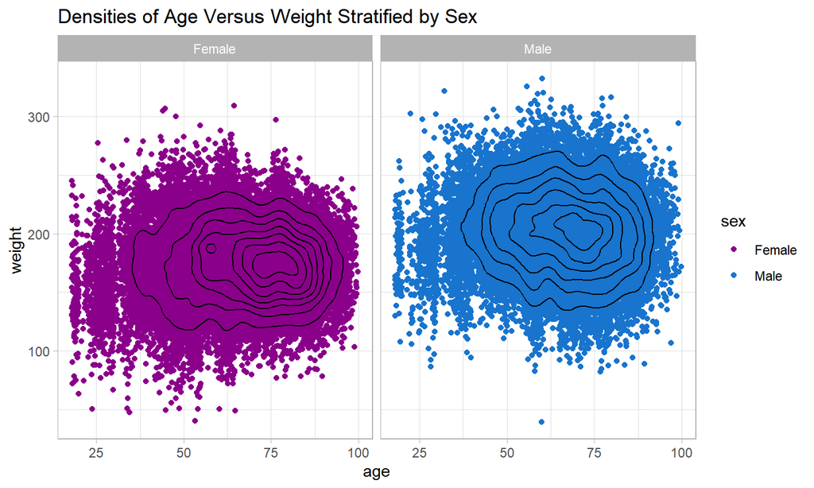

```r
ggplot(DIABETES_CLASS,aes(x=age, y=weight, color=sex)) +
  geom_point() +
  ggtitle(label = "Densities of Age Versus Weight Stratified by Sex") +
  scale_color_manual(values=c("magenta4","dodgerblue3")) +
  geom_density_2d(color="black") +
  facet_grid(. ~ sex) +
  theme_light()
```

## Exercise 3

## Exercise 3

- 1.) Start with a basic scatter plot of age vs weight.
- 2.) Add a title and axis labels.
- 3.) Use geom_density_2d() to add the 2d kernel density.
- 4.) Color by smoking status and set manual colors.
- 5.) Facet by smoking status.
- 6.) Add a theme
- 7.) (Bonus) Clean up the legend and facet labels.

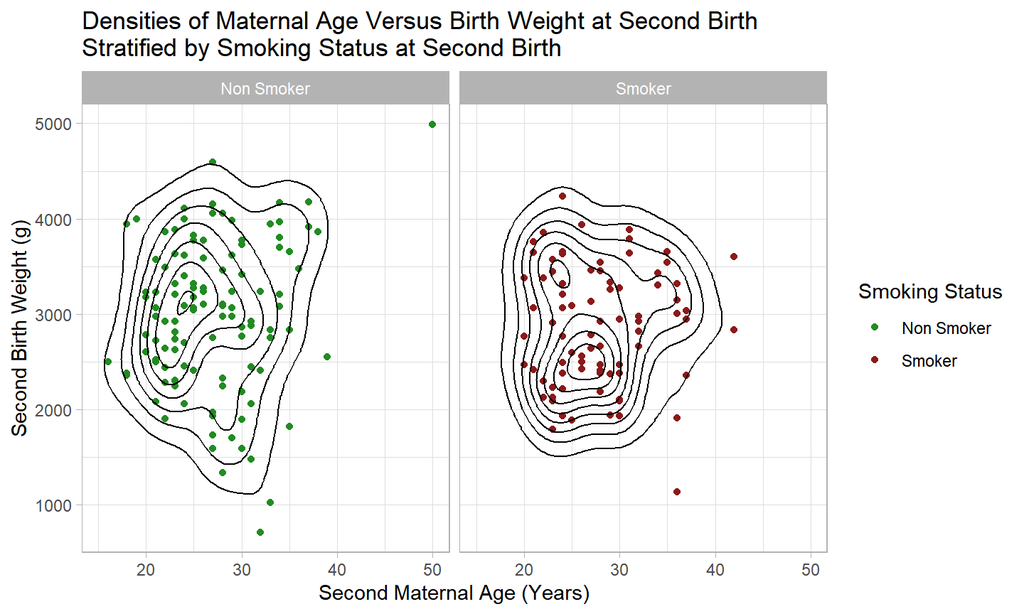

## Recreating Example 3

## Example 3

This plot demonstrates the relationship between age and the number of lab procedures performed during the encounter.

Linear regression lines are plotted for each admin type.

- geom_smooth() is used to create the regression lines.
- https://ggplot2.tidyverse.org/reference/geom_smooth.html
- annotate() is used to add on the sample sizes of each admin type.
- https://ggplot2.tidyverse.org/reference/annotate.html

## Example 3

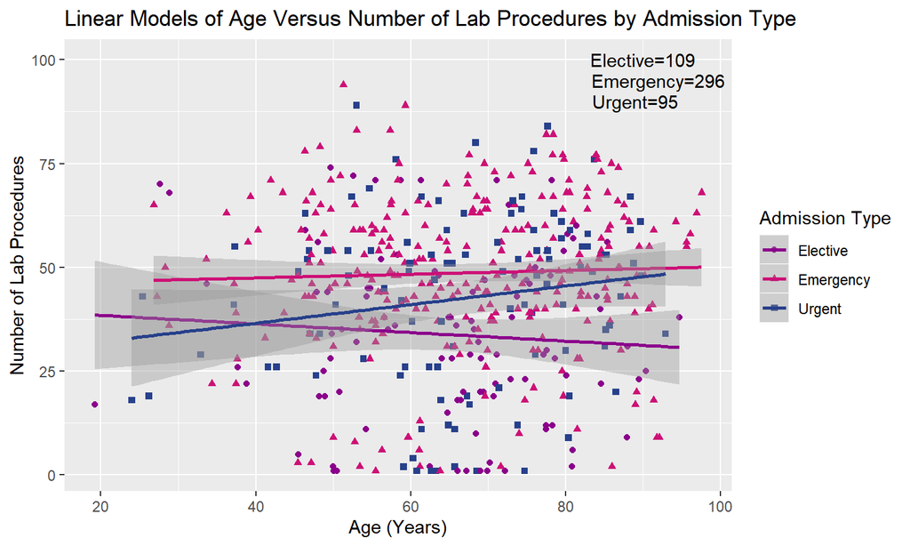

## Recreating Example 3

For demonstration purposes, we will take a sample of the data to display different graphical options.

Then we will start with a scatter plot including a title and axis labels.

```r
#Taking a sample of 500
set.seed(15)
DIABETES_SAMPLE <- DIABETES_CLASS %>%
  filter(!sex=="Unknown/Invalid" & !admin_type == "Missing" & !admin_type == "Other") %>%
  sample_n(size=500)

ggplot(DIABETES_SAMPLE,aes(x=age, y=num_lab_procedures))  +
  ggtitle("Linear Models of Age Versus Number of Lab Procedures by Admission Type") +
  xlab("Age (Years)") + ylab("Number of Lab Procedures") +
  geom_point()
```

## Recreating Example 3

Add the regression lines

- geom_smooth() will draw certain curves for us.
- The parameter "method" is used to determine what kind of curve to draw.
- method = "lm" gives a linear regression line.

```r
#Taking a sample of 500
set.seed(15)
DIABETES_SAMPLE <- DIABETES_CLASS %>%
  filter(!sex=="Unknown/Invalid" & !admin_type == "Missing" & !admin_type == "Other") %>%
  sample_n(size=500)

ggplot(DIABETES_SAMPLE,aes(x=age, y=num_lab_procedures)) +
  ggtitle("Linear Models of Age Versus Number of Lab Procedures by Admission Type") +
  xlab("Age (Years)") + ylab("Number of Lab Procedures") +
  geom_point() +
  geom_smooth(method = "lm")
```

## Recreating Example 3

Add colors and shapes. We will also manually set the colours, shapes, and legend name.

- Here we are setting admin_type to both color and shape
- Notice how geom_smooth plots 3 regression lines based off the way we set up our aesthetics

```r
#Taking a sample of 500
set.seed(15)
DIABETES_SAMPLE <- sample_n(DIABETES_CLASS,size=500)

ggplot(DIABETES_SAMPLE,aes(x=age, y=num_lab_procedures, color=admin_type, shape=admin_type))  +
  ggtitle("Linear Models of Age Versus Number of Lab Procedures by Admission Type") +
  xlab("Age (Years)") + ylab("Number of Lab Procedures") +
  geom_point() +
  geom_smooth(method="lm") +
  scale_color_manual(values=c("magenta4","deeppink3","royalblue4"),
                     name = "Admission Type") +
  scale_shape_manual(values=c("circle","triangle","square"),
                     name = "Admission Type")
```

## Recreating Example 3

Add in the sample sizes via annotate()

- geom determines the type of annotation, here we use "text"
- x and y are the corresponding coordinates for each label
- label is the name for each label

```r
#Taking a sample of 500
set.seed(15)
DIABETES_SAMPLE <- sample_n(DIABETES_CLASS,size=500)

ggplot(DIABETES_SAMPLE,aes(x=age, y=num_lab_procedures, color=admin_type, shape=admin_type))  +
  ggtitle("Linear Models of Age Versus Number of Lab Procedures by Admission Type") +
  xlab("Age (Years)") + ylab("Number of Lab Procedures") +
  geom_point() +
  geom_smooth(method="lm") +
  scale_color_manual(values=c("magenta4","deeppink3","royalblue4"),
                     name = "Admission Type") +
  scale_shape_manual(values=c("circle","triangle","square"),
                     name = "Admission Type") +
  annotate(geom="text",
           x=c(90,92,89),
           y=c(100,95,90),
           label = c("Elective=109", "Emergency=296", "Urgent=95"))
```

## Exercise 4

## Exercise 4

- 1.) Create a basic scatter plot of maternal age versus maternal weight at first birth.
- 2.) Add a title and axis labels.
- 3.) Color by history of uterine irritability and set manual colors.
- 4.) Change the shape by history of uterine irritability.
- 5.) Use geom_smooth() to add the regression lines.
- 6.) (Bonus) Use annotate() to add the sample size for history of uterine irritability (UI=30, No UI=170).
- 7.) (Bonus) Change the line type for each regression line.

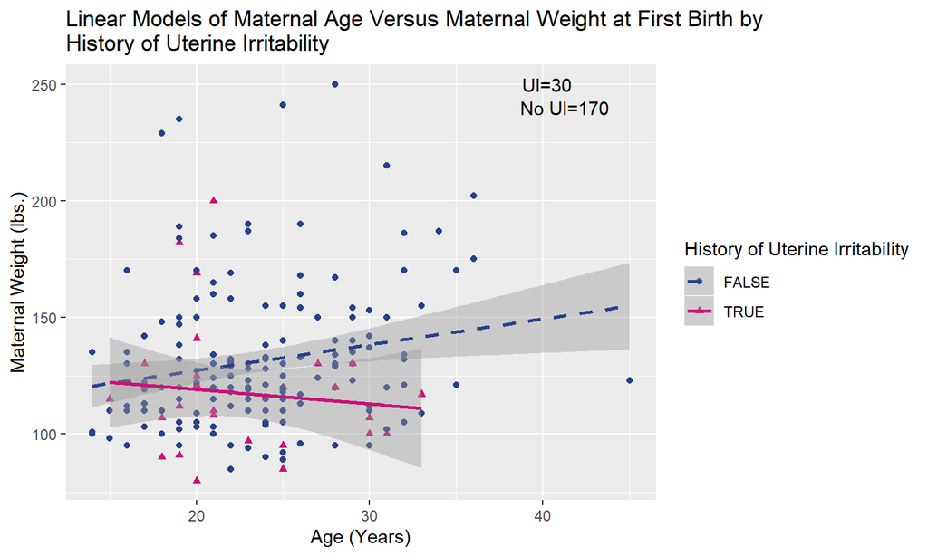

## Take Home Exercise

R for Data Science is an excellent resource for learning more about ggplot.

- A free online version can be found here: https://r4ds.had.co.nz/

We recommend you try the following exercises as homework:

- Exercise 3.3.1 (Questions 1,3,4)
- Exercise 3.5.1 (Questions 1-4)